# Lab 4: Spatial Regression

Femi Olamijulo

Today, we’ll be examining regression models that account for spatial dependency (e.g., spatial lag and spatial regression models).We’re going to be concerned with model evaluation; how do we decide which model to use, once we decide that spatial dependence is something we have to account for? We’ll discuss three primary means of evaluating our models:

1. Lagrange Multiplier tests.
2. The Akaike Information Criterion, or AIC.
3. Log-likelihood approaches.

Once again, we’ll be using data drawn from the [Eviction Lab at Princeton University](https://evictionlab.org/). I’ll also, again, draw your attention to the fact that there have been substantial critiques of both [the data and the lab’s approach](https://shelterforce.org/2018/08/22/eviction-lab-misses-the-mark/). While we won’t be delving deep into the problems raised by the authors of the Shelterforce piece, they are salient! And any analysis undertaken with this data should reckon with them.

## Getting Ready

We begin by loading the necessary libraries—for spatial regression, `spdep` and `spatialreg` are the important libraries to note. The former provides functions that allow us to easily construct weights matricies, and the latter offers extensions of the `lm` function that account for spatial dependence. We also read the provided `.geojson` file and store it in a new Simple Features (`sf`) dataframe.

```r
library(sf)
library(RColorBrewer)
library(leaflet)
library(dplyr)
library(spdep)
library(spatialreg)
tracts <- st_read('data/eviction_by_tract.geojson')
```

Plotting a histogram of our observed median household incomes

```r
hist(tracts$median_household_income,
     main = "Before Filtering",
     xlab = "Median Household Income")
```

[figure not shown]

Because the distribution of Median Household Income is close to a normal distribution, I will not log the variable.

## Test Response Variable for Autocorrelation

As we know, we can test for autocorrelation using a Moran’s I test and We create a row-normalized weights matrix using rook contiguity and test.

```r
tracts <- tracts %>% filter(median_household_income >0)%>%filter(median_property_value>0)%>% filter(pct_nonwhite_log >0)%>% filter(evic_filing_rate_log>0)%>%filter(pov_rate_log >0)
weights <- nb2listw(poly2nb(tracts, queen = FALSE), style="W")
medhousehold_inc <- moran.test(tracts$median_household_income, weights)
medhousehold_inc
```

```
##
##  Moran I test under randomisation
##
## data:  tracts$median_household_income
## weights: weights
##
## Moran I statistic standard deviate = 18.82, p-value < 2.2e-16
## alternative hypothesis: greater
## sample estimates:
## Moran I statistic       Expectation          Variance
##      0.5632672549     -0.0018587361      0.0009016459
```

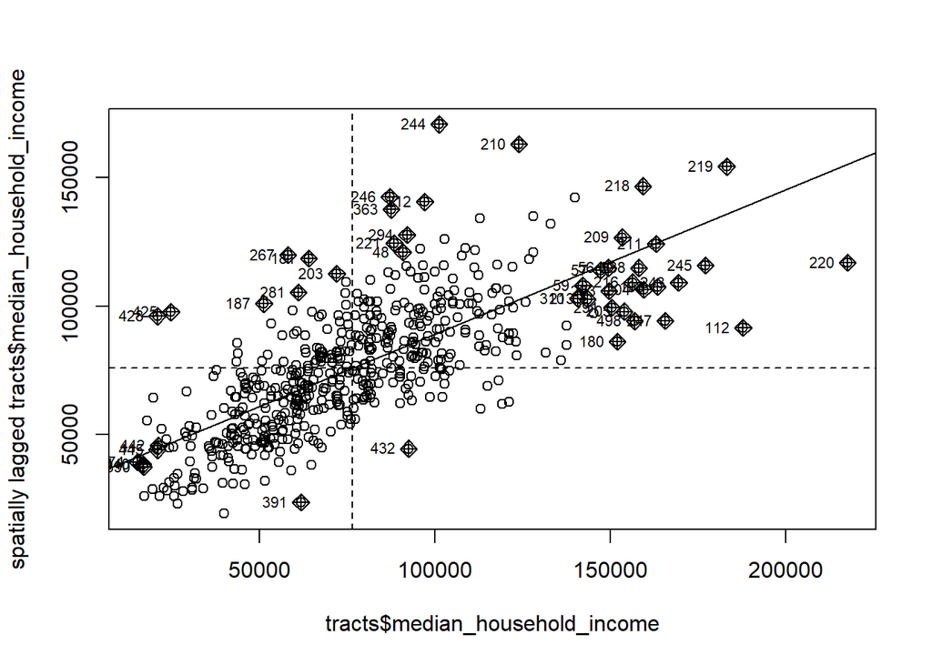

```r
moran.plot(tracts$median_household_income, weights)
```

We see statistically significant spatial autocorrelation! High moran’s I of 0.56 However, the presence of autocorrelation in our response variable does *not* necessarily mean that our models will see autocorrelation in their errors. This is because our explanatory variables *may* account for the clustering behavior. Spatial regression becomes necessary, not when the dependent variable is autocorrelated, but when we see autocorrelation in the residuals of an OLS model.

## Run Standard OLS

Recall that a standard OLS model is specified like this:

$$y = \beta_{0} + \beta_{1}x_{1} + \beta_{2}x_{2} + ... + \beta_{n}x_{n} +
\epsilon$$

We assume, given patterns of racialized disinvestment and the association between income and property values, that the property values, eviction rate, poverty rate and the percentage of a population identifying as non-white will account for some variation in median household incomes.

```r
ols <- lm(
  formula = median_household_income ~ median_property_value + pct_nonwhite_log + evic_filing_rate_log + pov_rate_log,
  data = tracts
  )
summary(ols)
```

```
##
## Call:
## lm(formula = median_household_income ~ median_property_value +
##     pct_nonwhite_log + evic_filing_rate_log + pov_rate_log, data = tracts)
##
## Residuals:
##    Min     1Q Median     3Q    Max
## -53196 -10168   -266  10436  57163
##
## Coefficients:
##                         Estimate Std. Error t value Pr(>|t|)
## (Intercept)            1.029e+05  4.535e+03  22.682  < 2e-16 ***
## median_property_value  8.965e-02  5.355e-03  16.741  < 2e-16 ***
## pct_nonwhite_log      -1.007e+04  1.399e+03  -7.199 2.06e-12 ***
## evic_filing_rate_log   1.198e+03  1.541e+03   0.778    0.437
## pov_rate_log          -1.551e+04  1.270e+03 -12.211  < 2e-16 ***
## ---
## Signif. codes:  0 '***' 0.001 '**' 0.01 '*' 0.05 '.' 0.1 ' ' 1
##
## Residual standard error: 17190 on 534 degrees of freedom
## Multiple R-squared:  0.7102, Adjusted R-squared:  0.708
## F-statistic: 327.1 on 4 and 534 DF,  p-value: < 2.2e-16
```

I found it interesting that eviction rates are positively correlated with higher median incomes. Our coefficient of determination, or $R^{2}$ is (.71).

The salient question for our purposes today is: have these explanatory variables accounted for the autocorrelation we observed in our response variable? To start, let’s map the residuals…

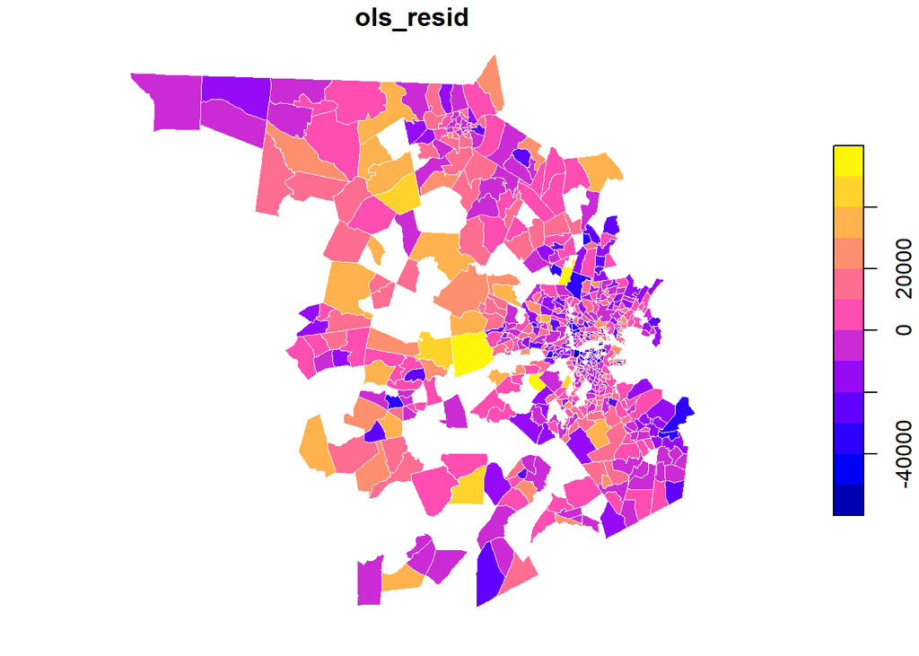

```r
tracts$ols_resid <- residuals(ols)
plot(tracts['ols_resid'],
     lwd=0.05,
     border=0)
```

Unfortunately, we have 10 missing observations and it’s hard to tell from visual inspection here if our residuals are autocorrelated.With our higher r-squared value, we expect that like values will tend to be near like values. We can test this using a Moran’s test…

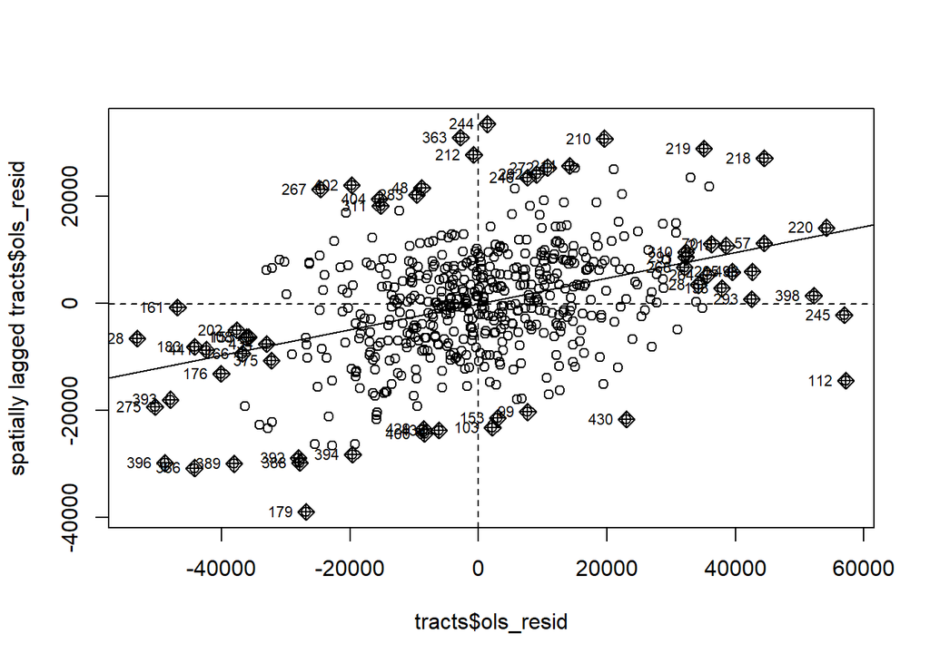

```r
moran.plot(tracts$ols_resid, weights)
```

```r
moran.test(tracts$ols_resid, weights)
```

```
##
##  Moran I test under randomisation
##
## data:  tracts$ols_resid
## weights: weights
##
## Moran I statistic standard deviate = 8.061, p-value = 3.785e-16
## alternative hypothesis: greater
## sample estimates:
## Moran I statistic       Expectation          Variance
##      0.2402377820     -0.0018587361      0.0009019952
```

While the value of the global Moran’s I is *less* positive (.24), it still indicates the presence of positive autocorrelation. This is the condition under which we consider applying spatial regression methods! Recall that we introduced two in lecture—spatial lag, in which lagged observations of the response variable are taken to explain autocorrelation in the response variable, and spatial error, in which lagged errors are taken to explain autocorrelation in the residuals. Let’s start with the the former case.

## Spatial Lag Modeling

A spatial lag model is given by…

$$Y = \beta_{0} + \beta_{1} X_{1} + ... + \beta_{n} X_{n} + \rho W y +
\epsilon$$

Where W is a weights matrix, $\rho$ (rho) is a spatial lag parameter. We’ve introduced a new term that asserts that our response variable is dependent on lagged (i.e., adjancent) values of itself.

Such a model can be fit using the `lagsarlm` function from the `spatialreg` library. The syntax is identical to a standard `lm` except we pass the weights list to the `listw` parameter.

```r
lag <- lagsarlm(
  formula = median_household_income ~ median_property_value + pct_nonwhite_log + evic_filing_rate_log + pov_rate_log,
  data = tracts,
  listw = weights)
summary(lag)
```

```
##
## Call:lagsarlm(formula = median_household_income ~ median_property_value +
##     pct_nonwhite_log + evic_filing_rate_log + pov_rate_log, data = tracts,
##     listw = weights)
##
## Residuals:
##       Min        1Q    Median        3Q       Max
## -60074.93  -9101.72   -123.26   9485.65  61742.27
##
## Type: lag
## Coefficients: (numerical Hessian approximate standard errors)
##                          Estimate  Std. Error  z value  Pr(>|z|)
## (Intercept)            7.2215e+04  5.7791e+03  12.4958 < 2.2e-16
## median_property_value  7.6912e-02  5.2667e-03  14.6035 < 2.2e-16
## pct_nonwhite_log      -7.1106e+03  1.3623e+03  -5.2197 1.792e-07
## evic_filing_rate_log   1.7942e+03  1.4347e+03   1.2505    0.2111
## pov_rate_log          -1.3389e+04  1.2187e+03 -10.9861 < 2.2e-16
##
## Rho: 0.2787, LR test value: 55.85, p-value: 7.816e-14
## Approximate (numerical Hessian) standard error: 0.0357
##     z-value: 7.8067, p-value: 5.7732e-15
## Wald statistic: 60.945, p-value: 5.8842e-15
##
## Log likelihood: -5990.822 for lag model
## ML residual variance (sigma squared): 2.59e+08, (sigma: 16094)
## Number of observations: 539
## Number of parameters estimated: 7
## AIC: 11996, (AIC for lm: 12049)
```

Our results tell us quite a lot. We have a `rho` value of 0.27, still indicating less positive autocorrelation between an observation of the response and lagged observations. It is highly significant(except for filing rate)! Furthermore, we note that all variables retain their respective positive or negative coefficients.

Model coefficients depict only direct effects, not indirect effects. We can parse these out using the `impacts` function.

```r
impacts(lag, listw=weights)
```

```
## Impact measures (lag, exact):
##                              Direct      Indirect         Total
## median_property_value  7.845353e-02  2.817581e-02  1.066293e-01
## pct_nonwhite_log      -7.253153e+03 -2.604899e+03 -9.858051e+03
## evic_filing_rate_log   1.830132e+03  6.572739e+02  2.487406e+03
## pov_rate_log          -1.365757e+04 -4.904981e+03 -1.856255e+04
```

This returns three columns: the direct effects of a unit change, which is to say the local effects; the indirect effects, which is to say the effect *of the effect* on its neighboring tracts, and the total, which estimates the total effect, including direct and indrect effects.

However, the question is: did this account for autoregression in our errors? Let’s see whether the residuals of the lag model are autocorrelated.

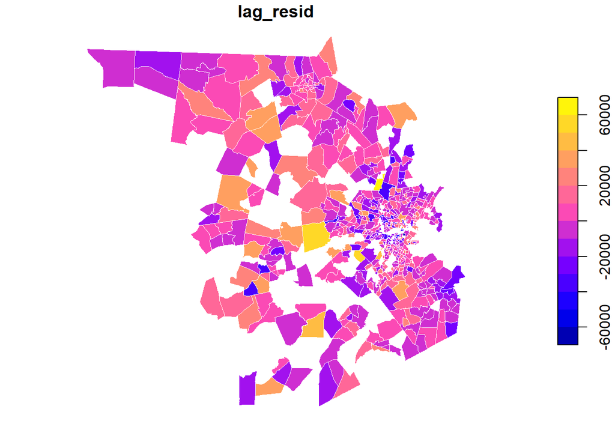

```r
tracts$lag_resid <- residuals(lag)
plot(tracts['lag_resid'],
     lwd=0.05,
     border=0
     )
```

A map of the model residuals suggests less pronounced clustering, and Moran tests confirm our visual inspection…

```r
moran.test(tracts$lag_resid, weights)
```

```
##
##  Moran I test under randomisation
##
## data:  tracts$lag_resid
## weights: weights
##
## Moran I statistic standard deviate = 1.4037, p-value = 0.0802
## alternative hypothesis: greater
## sample estimates:
## Moran I statistic       Expectation          Variance
##      0.0402902283     -0.0018587361      0.0009016119
```

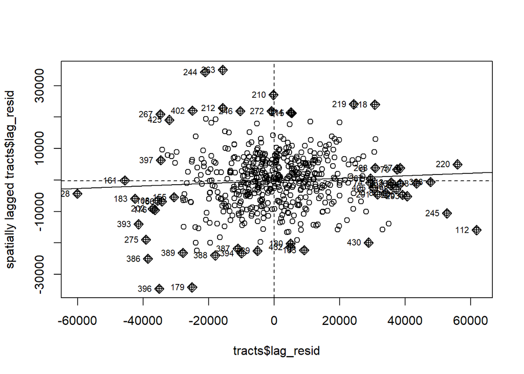

```r
moran.plot(tracts$lag_resid, weights)
```

However, we also have other tools available to us! Instead of a spatial lag model, we could have fit a spatial error model. We’ll do this now… to give away the secret a bit, we’ll find that it also performs fairly well. Which will beg the question: which model do we use?

## Spatial Error Modeling

In a spatial error model, we assume that our errors (our residuals) are dependent on lagged error terms. In practice, this generally means that we’re assuming that spatial auto-correlation is due to a variable we have not accounted for.

$$Y = \beta_{0} + \beta_{1} X_{1} + ... + \beta_{n} X_{n} + u \\
u = \lambda W u + \epsilon$$

Here, the error term ($\epsilon$) is decomposed into a spatially lagged error term ($\lambda W u$) and an identically and independently distributed error term ($\epsilon$). $\lambda$ is very similar to $\rho$ in the spatial lag model—it indicates the presence of positive, negative or no autocorrelation.

Much like the `lagsarlm` function above, we can fit a spatial error model using…

```r
err <- errorsarlm(
  formula = median_household_income ~ median_property_value + pct_nonwhite_log + evic_filing_rate_log + pov_rate_log,
  data = tracts,
  listw = weights
  )
summary(err)
```

```
##
## Call:errorsarlm(formula = median_household_income ~ median_property_value +
##     pct_nonwhite_log + evic_filing_rate_log + pov_rate_log, data = tracts,
##     listw = weights)
##
## Residuals:
##       Min        1Q    Median        3Q       Max
## -55292.13  -9009.91   -159.38   9307.66  62275.26
##
## Type: error
## Coefficients: (asymptotic standard errors)
##                          Estimate  Std. Error z value  Pr(>|z|)
## (Intercept)            9.7570e+04  5.7209e+03 17.0551 < 2.2e-16
## median_property_value  9.5320e-02  6.0214e-03 15.8301 < 2.2e-16
## pct_nonwhite_log      -1.0817e+04  1.5937e+03 -6.7876  1.14e-11
## evic_filing_rate_log  -1.2364e+03  1.6575e+03 -0.7459    0.4557
## pov_rate_log          -1.1476e+04  1.2196e+03 -9.4093 < 2.2e-16
##
## Lambda: 0.44659, LR test value: 64.307, p-value: 1.1102e-15
## Approximate (numerical Hessian) standard error: 0.049324
##     z-value: 9.0543, p-value: < 2.22e-16
## Wald statistic: 81.981, p-value: < 2.22e-16
##
## Log likelihood: -5986.593 for error model
## ML residual variance (sigma squared): 246590000, (sigma: 15703)
## Number of observations: 539
## Number of parameters estimated: 7
## AIC: 11987, (AIC for lm: 12049)
```

The eviction rate here is now negative though, like the lag test, it’s still not significant.This makes me wonder if this points so some level of rationality in the population. Perhaps people (rich or poor) do not like to be evicted and will usually go for housing they can comfortably afford.

Inspecting a map for autocorrelation in model residuals, we again see a distribution that leads us to suspect that we’ve eliminated spatial autocorrelation.

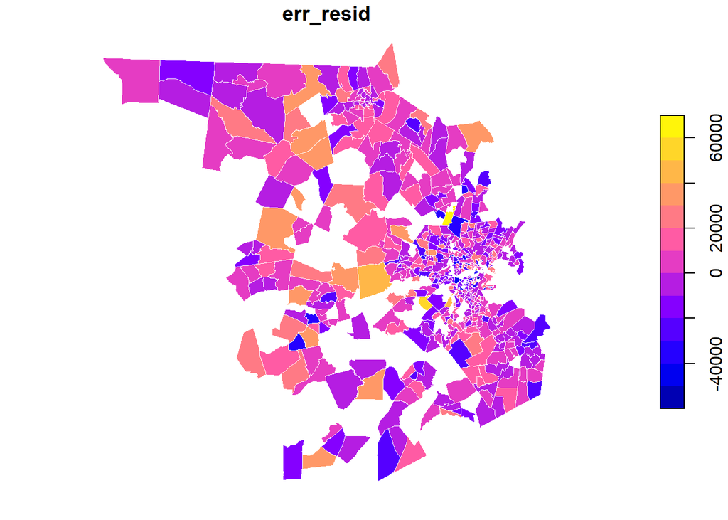

```r
tracts$err_resid <- residuals(err)
plot(tracts['err_resid'],
     lwd=0.05,
     border=0)
```

Our Moran tests and plots indicate the same.

```r
moran.test(tracts$err_resid, weights)
```

```
##
##  Moran I test under randomisation
##
## data:  tracts$err_resid
## weights: weights
##
## Moran I statistic standard deviate = -0.85309, p-value = 0.8032
## alternative hypothesis: greater
## sample estimates:
## Moran I statistic       Expectation          Variance
##     -0.0274721811     -0.0018587361      0.0009014656
```

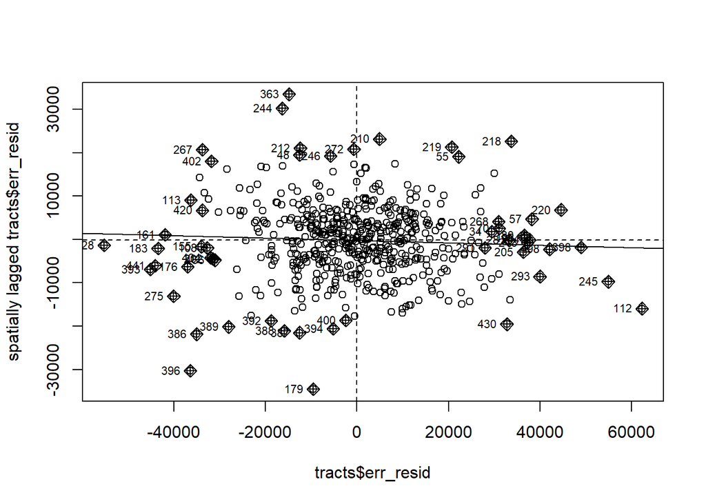

```r
moran.plot(tracts$err_resid, weights)
```

## So Which Do we Choose?

1. Akaike Information Criterion (AIC)
2. Lagrange Multipliers
3. Log-Likelihood Values

## Akaike Information Criterion

The AIC is a statistic used to evaluate model fit. It is given by…

$$AIC = 2k - 2 \ln({\hat{L}})$$

In the above, $k$ is the number of parameters estimated in the model, and $\ln({\hat{L}})$ is the log-likelihood. The notion here is that a model is penalized for modeling too many parameters… in other words, overfitting, or the inflation of model fit through the addition of parameters, is discouraged. As $k$ increases, the score increases. As the likelihood increases, the value of the AIC decreases.

This means that we’re going to tend to try and minimize the AIC. Our models above give results like this…

```r
AIC(ols, err, lag)
```

|  | df | AIC |
| --- | --- | --- |
| ols | 6 | 12049.49 |
| err | 7 | 11987.19 |
| lag | 7 | 11995.64 |

### Log-Likelihood

On this basis, we should choose the spatial error model. Similarly, we could choose the model based on the log-likelihood alone—this is similar to the AIC, but not penalize the model for overfitting. We can examine the relationships between these evaluative criteria by printing an ANOVA table…

```r
anova(err, lag)
```

|  | Model | df | AIC | logLik |
| --- | --- | --- | --- | --- |
| err | 1 | 7 | 11987.19 | -5986.593 |
| lag | 2 | 7 | 11995.64 | -5990.822 |

We are attempting to *minimize* the AIC and *maximize* the log-likelihood. In this case, these criteria are both met by the `err` model.

### Lagrange Multiplier Tests

```r
legrange <- lm.LMtests(ols, weights, test='all')
legrange
```

```
##
##  Lagrange multiplier diagnostics for spatial dependence
##
## data:
## model: lm(formula = median_household_income ~ median_property_value +
## pct_nonwhite_log + evic_filing_rate_log + pov_rate_log, data = tracts)
## weights: weights
##
## LMerr = 63.38, df = 1, p-value = 1.665e-15
##
##
##  Lagrange multiplier diagnostics for spatial dependence
##
## data:
## model: lm(formula = median_household_income ~ median_property_value +
## pct_nonwhite_log + evic_filing_rate_log + pov_rate_log, data = tracts)
## weights: weights
##
## LMlag = 63.29, df = 1, p-value = 1.776e-15
##
##
##  Lagrange multiplier diagnostics for spatial dependence
##
## data:
## model: lm(formula = median_household_income ~ median_property_value +
## pct_nonwhite_log + evic_filing_rate_log + pov_rate_log, data = tracts)
## weights: weights
##
## RLMerr = 11.929, df = 1, p-value = 0.0005528
##
##
##  Lagrange multiplier diagnostics for spatial dependence
##
## data:
## model: lm(formula = median_household_income ~ median_property_value +
## pct_nonwhite_log + evic_filing_rate_log + pov_rate_log, data = tracts)
## weights: weights
##
## RLMlag = 11.838, df = 1, p-value = 0.0005803
##
##
##  Lagrange multiplier diagnostics for spatial dependence
##
## data:
## model: lm(formula = median_household_income ~ median_property_value +
## pct_nonwhite_log + evic_filing_rate_log + pov_rate_log, data = tracts)
## weights: weights
##
## SARMA = 75.218, df = 2, p-value < 2.2e-16
```

Both of our non-robust tests are statistically significant, so we turn to the robust forms. Between our two robust forms, the error model has a higher LM value and lower p-value. This suggests that the error model is the more appropriate model, agreeing with our model evaluation using the AIC and Log-likelihood metrics.

## Summary

In this lab, we fitted both spatial lag and spatial error models, noting some of the differences in interpretation and evaluation between the two models. Both models addressed the presence of autocorrelation in our residuals… which raised the question of which model we should select. We addressed three common statistics used to evaluate model fit: the AIC (which we try to minimize), the log-likelihood (which we try to maximize), and the legrange multiplier (which we try to maximize). All three means of evaluation told us the same thing: that the spatial error model was a better fit given our observed data. This process is summarized in a useful flowchart developed by Luc Anselin…

[figure not shown]

Flowchart developed by Luc Anselin, reprinted in an excellent tutorial by Dr. Emily Burchfield.

## Take-Home

Your take-home exercise is to…

1. Fit a different model using a different collection of independent variables. Determine whether a spatial error model or a spatial lag model is more appropriate. Compare your results to those obtained in the course of the lab exercise.

Remember that the dataset I’ve provided, via the Eviction Lab, contains a range of demographic variables; these are from the American Community Survey 5-year product (2012-2016) and most are named in a self-explanatory way.